# Datos Georeferenciados

ggplot2 aplicado a la ubicación de pozos de YPF en Neuquen

Autor/a

Ciencia de Datos

Fecha de publicación

7 de julio de 2026

## Introducción

Los datos georreferenciados son observaciones asociadas explícitamente a una localización en el espacio, representada mediante coordenadas o geometrías (puntos, líneas o polígonos) dentro de un sistema de referencia geográfico. Su incorporación permite integrar la dimensión espacial al análisis estadístico, revelando patrones, relaciones y heterogeneidades territoriales que no son evidentes en datos convencionales.

En esta sección vamos a trabajar con la base `ypf_neuquen.xlsx`, que tiene **3 hojas** relacionadas: información de cada pozo, sus coordenadas y la formación geológica a la que pertenece. En total son **3.617 pozos** distribuidos por la Cuenca Neuquina.

La pregunta guía: ¿Dónde están los pozos de YPF en Neuquén y cómo se distribuyen?

## Setup

Necesitamos las siguientes librerías:

```r
library(tidyverse)   # ggplot2 + dplyr + readr + ...
library(readxl)      # leer .xlsx
library(sf)          # objetos espaciales
library(ggrepel)     # etiquetas que no se superponen
```

## 1. Cargar datos

La base viene en **3 hojas** de un mismo Excel. El archivo completo es chico pero tiene estructura relacional: las hojas se conectan por identificadores (id).

```r
pozos      <- read_xlsx("ypf_neuquen.xlsx", sheet = "Pozo")
ubicacion  <- read_xlsx("ypf_neuquen.xlsx", sheet = "Ubicacion")
formacion  <- read_xlsx("ypf_neuquen.xlsx", sheet = "Formacion")
```

### Un vistazo rápido a cada tabla

```r
glimpse(pozos)
```

```
Rows: 3,617
Columns: 7
$ idpozo       <dbl> 1, 2, 3, 4, 5, 6, 7, 8, 9, 10, 11, 12, 13, 14, 15, 16, 17…
$ tipoestado   <chr> "En Estudio", "En Estudio", "En Estudio", "En Estudio", "…
$ tipopozo     <chr> "Otro tipo", "Otro tipo", "Otro tipo", "Otro tipo", "Otro…
$ profundidad  <dbl> 3600, 2776, 3650, 3026, 2215, 3126, 3160, 3700, 2710, 376…
$ idubicacion  <dbl> 1, 2, 3, 4, 5, 6, 7, 8, 9, 10, 11, 12, 13, 14, 15, 16, 17…
$ idyacimiento <dbl> 1, 1, 2, 3, 4, 3, 2, 2, 2, 2, 2, 2, 2, 2, 2, 2, 2, 2, 2, …
$ idformacion  <dbl> 1, 1, 2, 1, 3, 1, 2, 2, 2, 2, 4, 2, 2, 5, 2, 2, 2, 2, 2, …
```

```r
glimpse(ubicacion)
```

```
Rows: 1,807
Columns: 3
$ idubicacion <dbl> 1, 2, 3, 4, 5, 6, 7, 8, 9, 10, 11, 12, 13, 14, 15, 16, 17,…
$ coordenadax <dbl> -68.90730, -68.91103, -68.92920, -68.74100, -69.23420, -68…
$ coordenaday <dbl> -38.39960, -38.40591, -38.74300, -38.22680, -37.25100, -38…
```

```r
glimpse(formacion)
```

```
Rows: 14
Columns: 2
$ idformacion <dbl> 1, 2, 3, 4, 5, 6, 7, 8, 9, 10, 11, 12, 13, 14
$ formacion   <chr> "vaca muerta", "lajas", "mulichinco", "lotena", "precuyo",…
```

## 2. Joinear todo en un solo dataframe

Para hacer el mapa necesitamos **coordenadas** (de `Ubicacion`) y **formación**.

```r
pozos_full <- pozos |>
  left_join(ubicacion, by = "idubicacion") |>
  left_join(formacion, by = "idformacion") |>
  mutate(formacion = str_to_title(formacion))
```

```r
pozos_full |>
  count(formacion, sort = TRUE) |>
  slice_head(n = 8)
```

```
# A tibble: 8 × 2
  formacion        n
  <chr>        <int>
1 Vaca Muerta   2419
2 Lajas          539
3 Mulichinco     306
4 Precuyo        104
5 Punta Rosada   101
6 Quintuco        84
7 Basamento       23
8 Lotena          14
```

**NotaDato interesante**

Hay **3.617 pozos** pero solo **1.807 ubicaciones**. Eso significa que **varios pozos comparten la misma locación**, son los famosos *pads*.

## 3. Primer representación

Un mapa no es nada misterioso. Las columnas `coordenadax` y `coordenaday` son números: **longitud** y **latitud** en grados decimales (scatter).

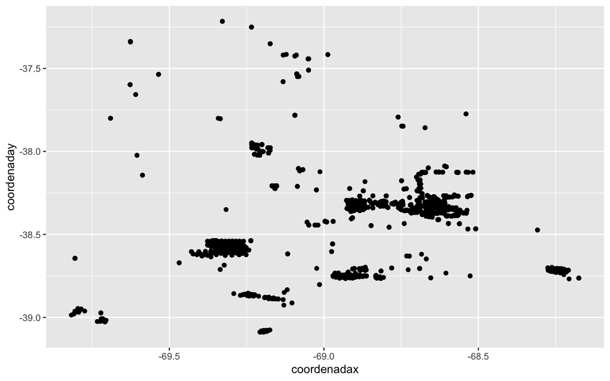

```r
ggplot(pozos_full, aes(x = coordenadax, y = coordenaday)) +
  geom_point()
```

¡Listo! Ya tenemos “el mapa de los pozos”. Pero la **proporción** entre el eje x y el eje y no es la real. A 38° de latitud sur, un grado de longitud es bastante más corto que un grado de latitud. La solución:

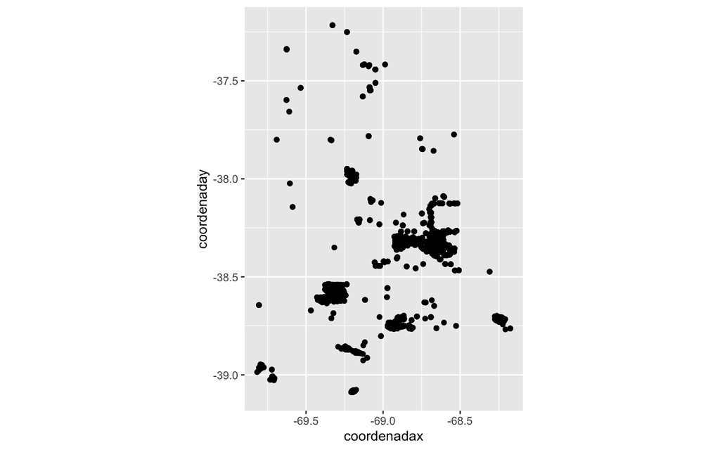

```r
ggplot(pozos_full, aes(x = coordenadax, y = coordenaday)) +
  geom_point() +
  coord_quickmap() #
```

**Tip`coord_quickmap()` vs `coord_sf()`**

`coord_quickmap()` es la solución rápida y conserva los ejes como números (lon/lat). Luego vamos a usar `coord_sf()`, que es la herramienta más adecuada.

## 4. Empezamos poco a poco

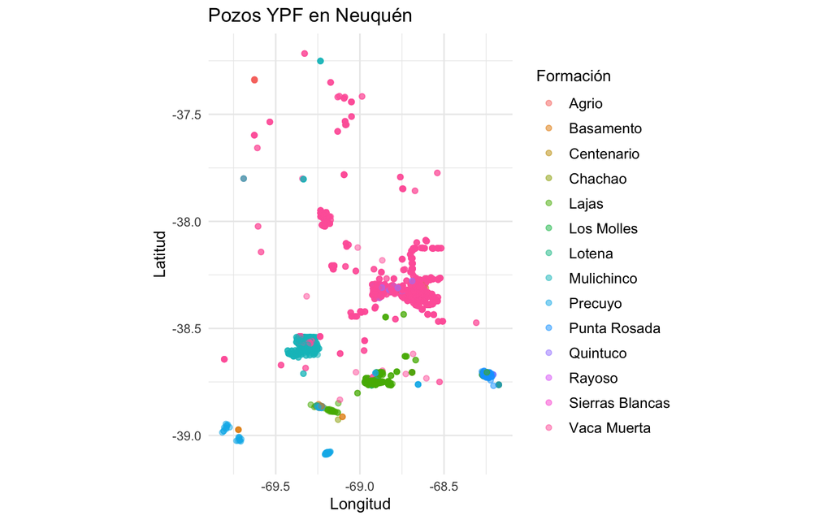

```r
ggplot(pozos_full,
       aes(coordenadax, coordenaday,
           color = formacion)) +
  geom_point(alpha = 0.5) +
  coord_quickmap() +
  labs(
    title = "Pozos YPF en Neuquén",
    x = "Longitud",
    y = "Latitud",
    color = "Formación"
  ) +
  theme_minimal() +
  theme(
    legend.position = "right",
    legend.text = element_text(size = 10)
  )
```

## 5. Etiquetas con `ggrepel`

```r
centros_form <- pozos_full|>
  group_by(formacion) |>
  summarise(
    cx = mean(coordenadax),
    cy = mean(coordenaday),
    n  = n(),
    .groups = "drop"
  )
```

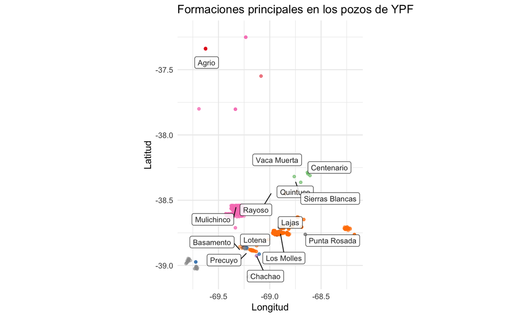

```r
ggplot(pozos_full, aes(x = coordenadax, y = coordenaday,
                          color = formacion)) +
  geom_point(size = 1.2, alpha = 0.5) +
  geom_label_repel(
    data = centros_form,
    aes(x = cx, y = cy, label = formacion),
    inherit.aes = FALSE,
    size = 3,
    fill = "white",
    alpha = 0.85
  ) +
  coord_quickmap() +
  scale_color_brewer(palette = "Set1") +
  labs(
    title = "Formaciones principales en los pozos de YPF",
    x = "Longitud", y = "Latitud",
    color = "Estado"
  ) +
  theme_minimal() +
  theme(legend.position = "none")
```

## 6. Ejercicios sugeridos:

Para resolver en clase o en casa.

1. **Filtra los pozos con `tipoestado == "Extracción Efectiva"`** y grafica su ubicación. ¿Se distribuyen igual que la base completa?
2. **Pintar los pozos por `profundidad` usando una escala continua** (por ejemplo `scale_color_viridis_c()`). Qué zona tiene los pozos más profundos?